# Dimkid: Singular Value Decomposition (SVD)

In this document, I explore 4 approaches to SVD with Dimkid data:

1. No mean-centering, characters as rows and capacities as columns
2. No mean-centering, capacities as rows and characters as columns
3. Mean-centering by capacity, characters as rows and capacities as columns (the classic approach)
4. Mean-centering by character, capacities as rows and characters as columns

# Raw data matrix visualizations

## Adults

In this study, 431 US adults rated 21 characters (between-subjects) on 40 capacities (within-subjects). (See Weisman, Dweck, & Markman, 2017, *PNAS*, Study 4.)

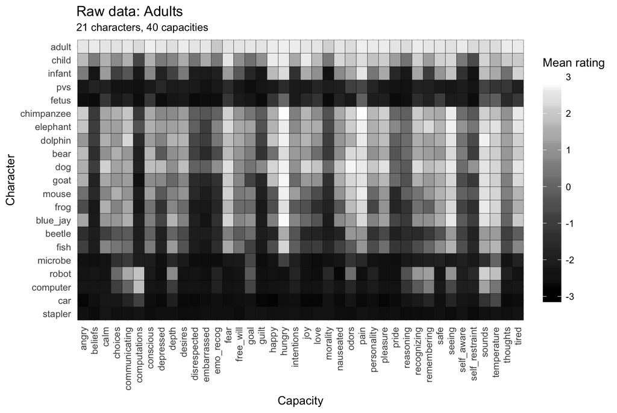

## 7-9yo children

In this study, 123 7- to 9-year-old US children rated 9 characters (between-subjects) on 20 capacities (within subjects). (See Weisman, Dweck, & Markman, 2018, *Proc. CogSci*.)

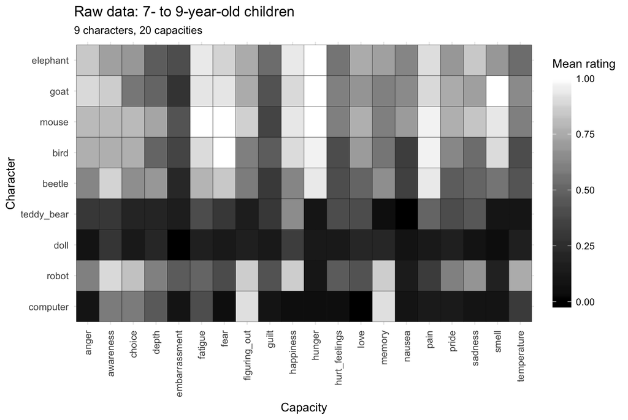

## 4-6yo children

In this study, 124 4- to 6-year-old US children rated 9 characters (between-subjects) on 20 capacities (within subjects). (See Weisman, Dweck, & Markman, 2018, *Proc. CogSci*.)

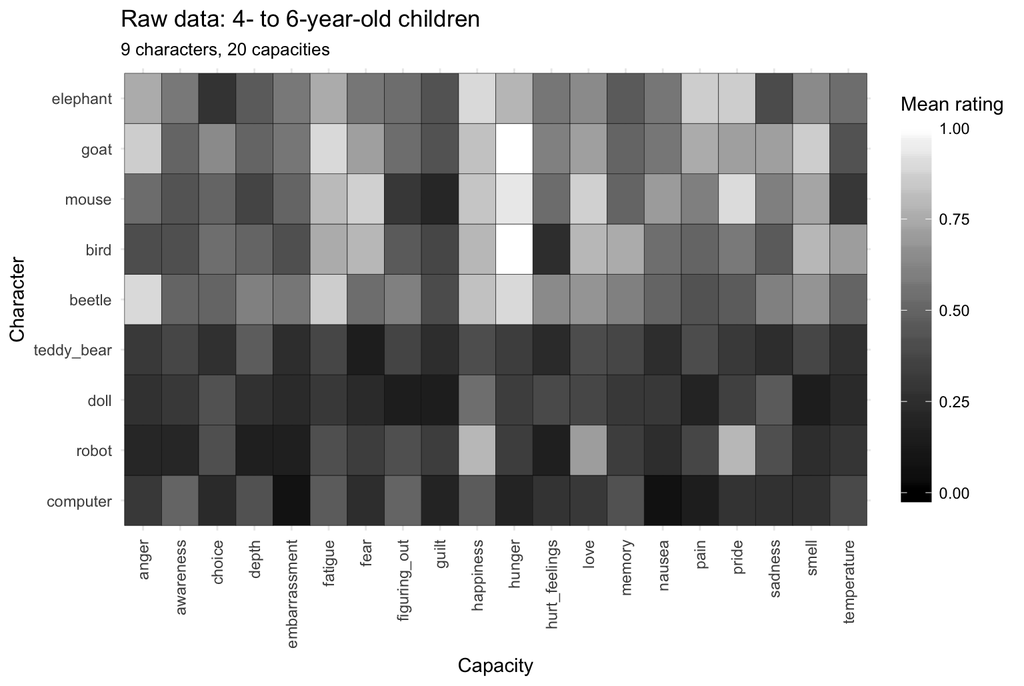

# Approach #1

In Approach #1 we proceed without mean-centering, with characters as rows and capacities as columns.

## Adults

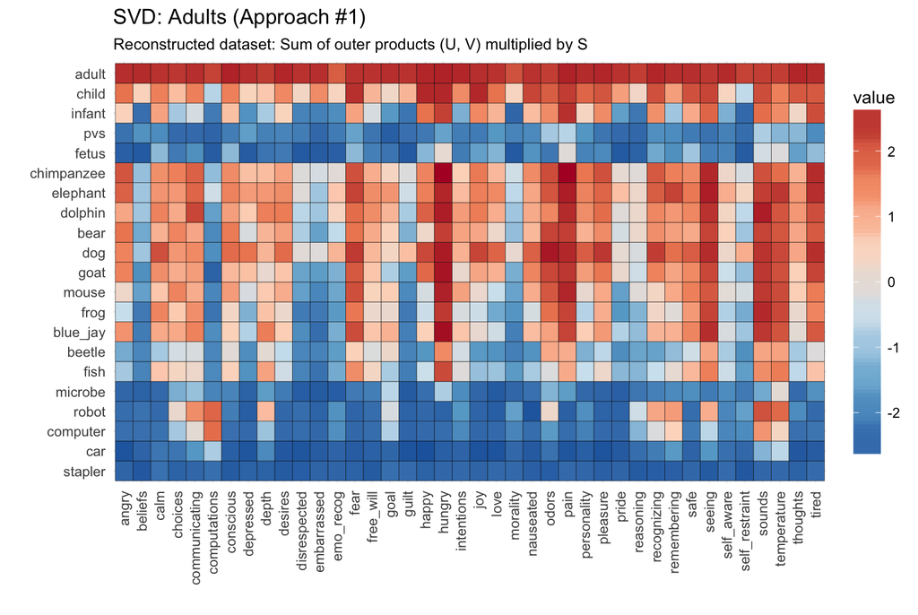

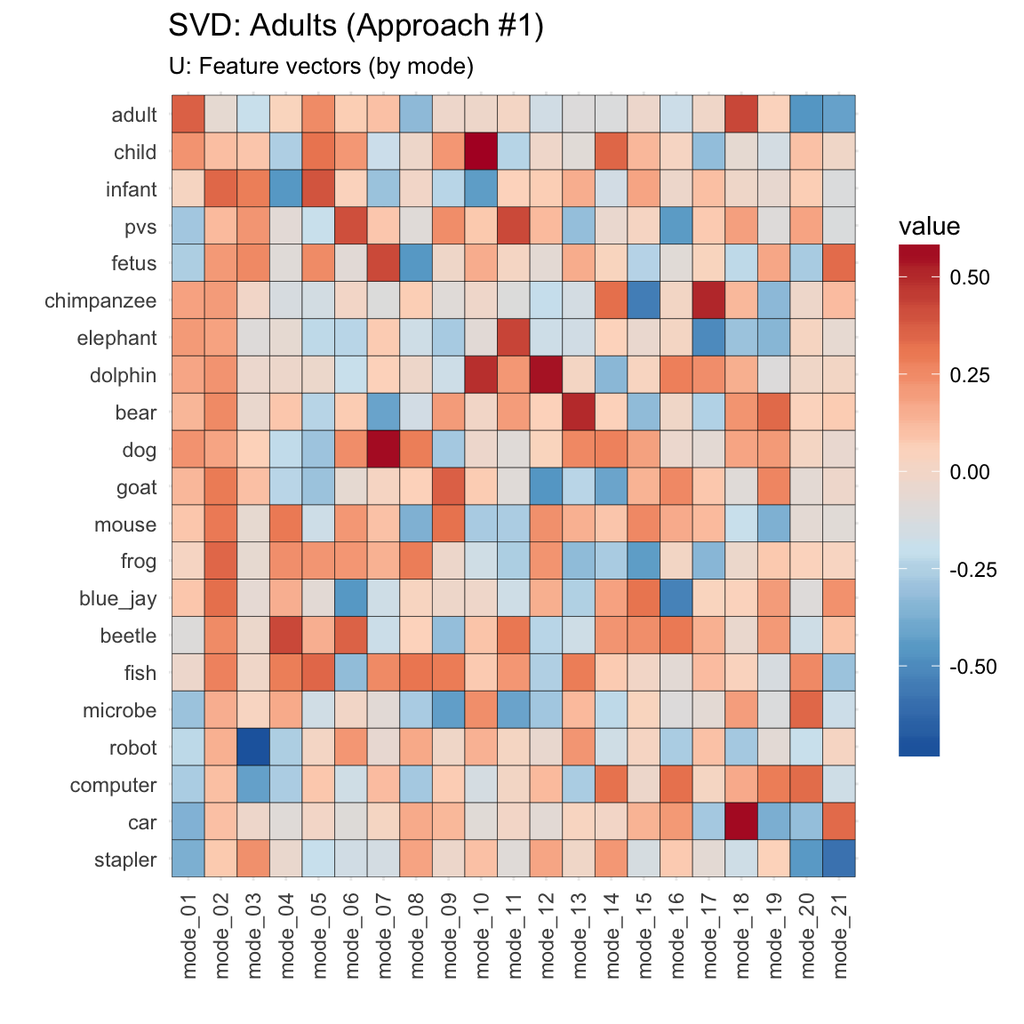

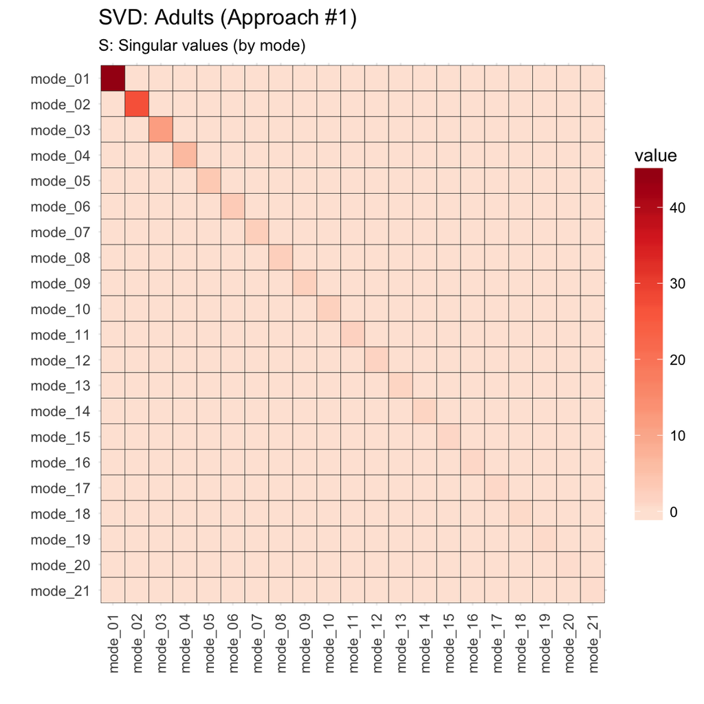

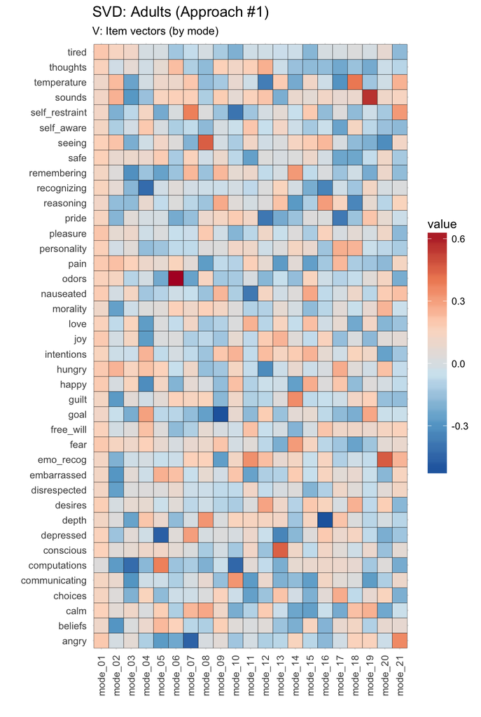

## 7-9yo children

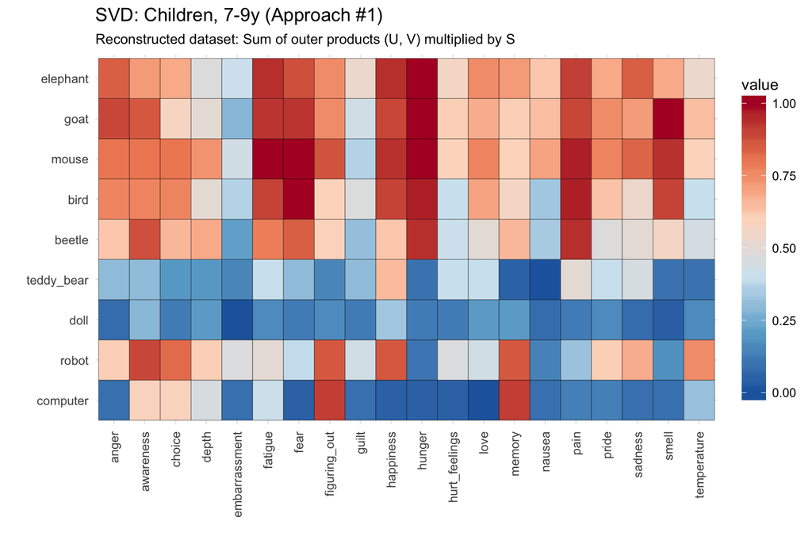

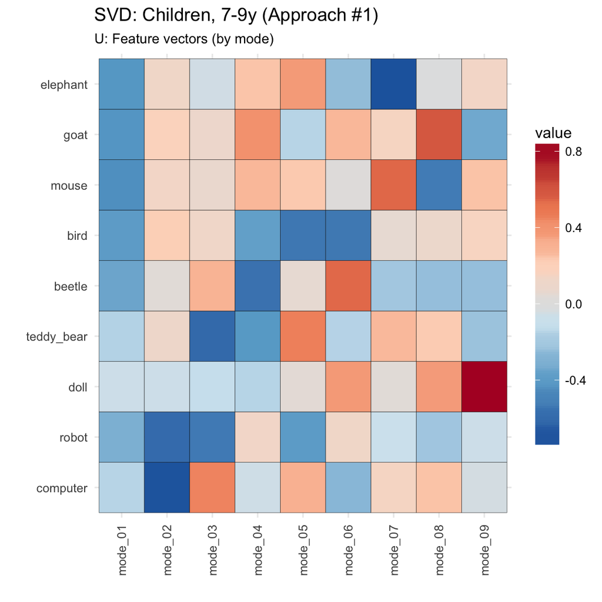

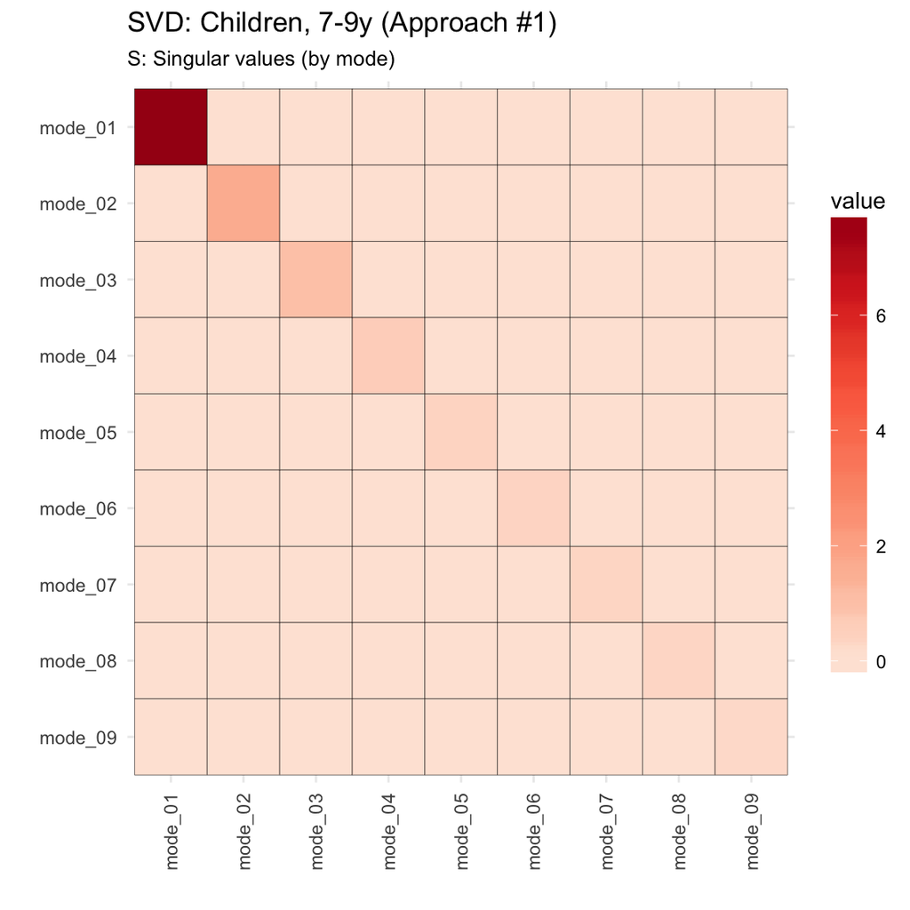

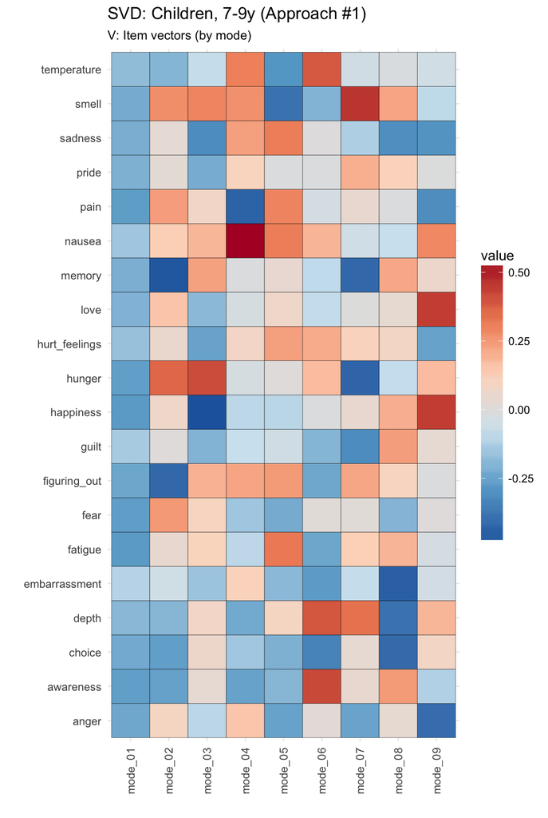

**Questions for Jay**:

- Some but not all of the modes are reversed, relative to Jay’s results from 2018-05-14 (modes #1, 3, 4, 7, and 9). Is this ok?

## 4-6yo children

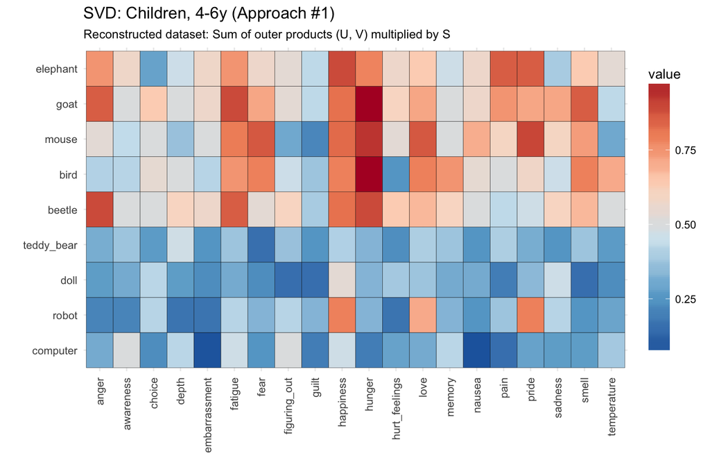

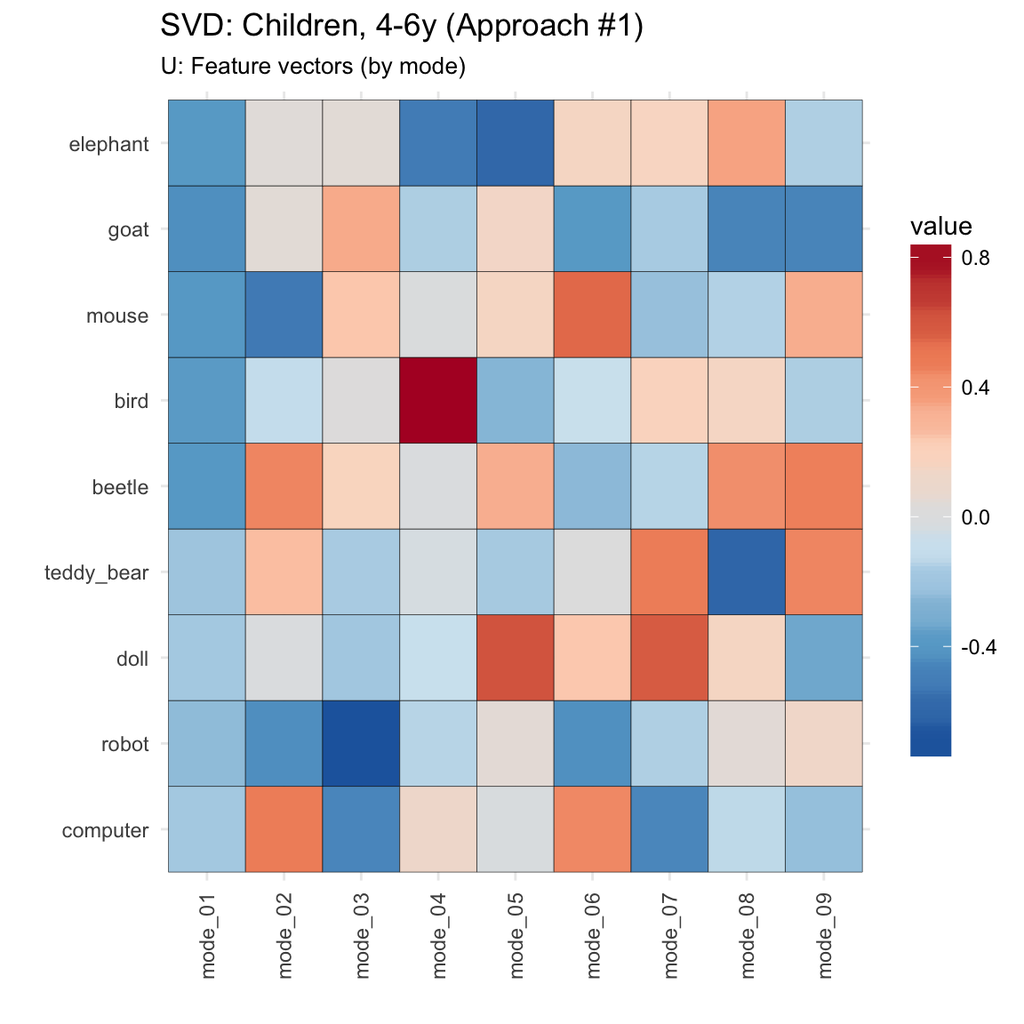

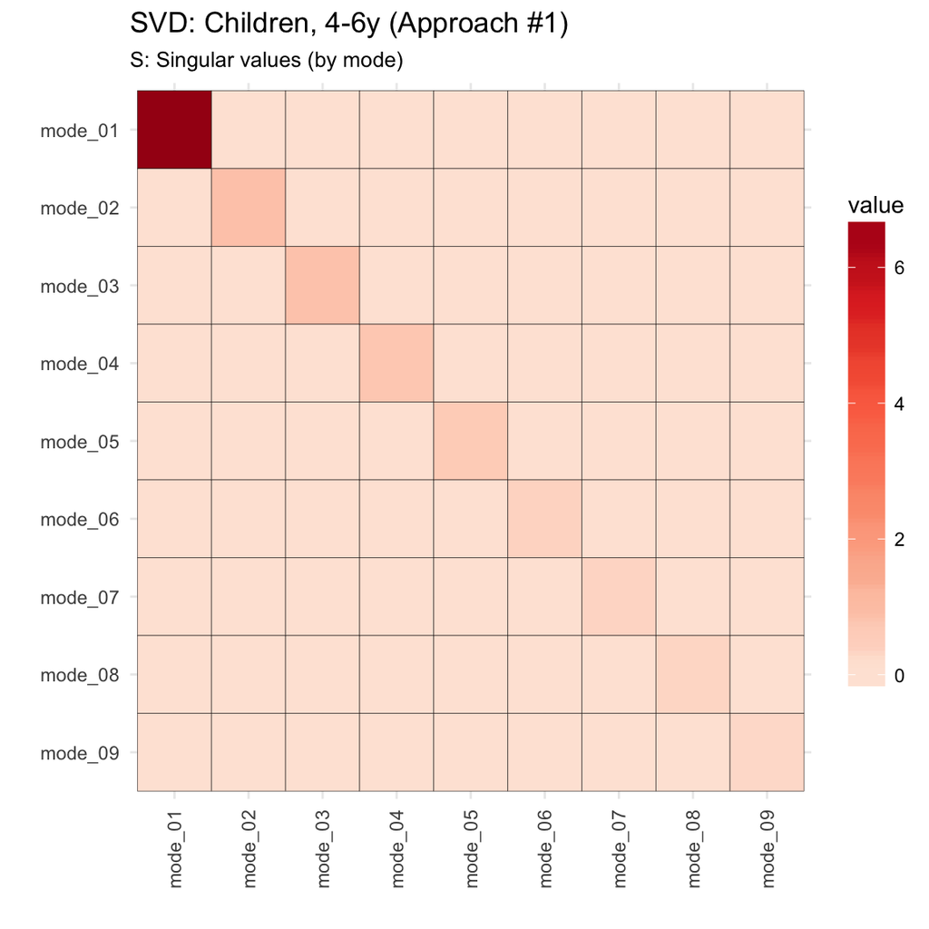

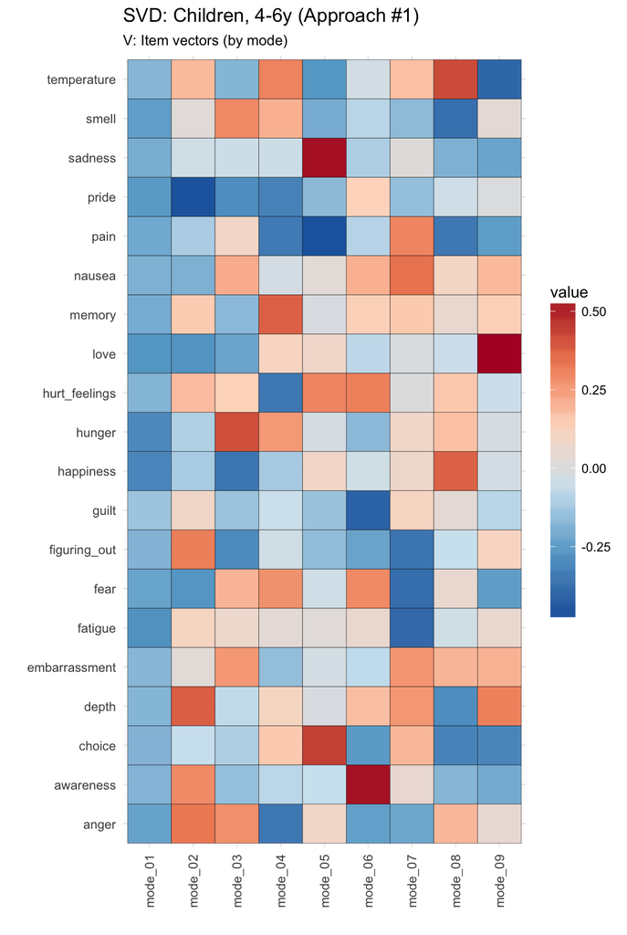

# Approach #2

In Approach #2 we proceed without mean-centering, with capacities as rows and characters as columns.

# Approach #3

In Approach #3 we mean-center by capacity, with characters as rows and capacities as columns.

# Approach #4

In Approach #4 we mean-center by character, with capacities as rows and characters as columns.